# Machine Learning Assignment 3 - Naive Bayes Classification

SrushtiP

10/24/2019

Problem Statment:

Predicting flight delays can be useful to a variety of organizations. Here, we look at five predictors. The outcome of interest is whether or not the flight is delayed (delayed here means arrived more than 15 minutes late). Our data consist of all flights from the Washington, DC area into the New York City area during January 2004. A record is a particular flight. The percentage of delayed flights among these 2201 flights is 19.5%. The data were obtained from the Bureau of Transportation Statistics (available on the web at www.transtats.bts.gov). The goal is to accurately predict whether or not a new flight (not in this dataset), will be delayed. The outcome variable is whether the flight was delayed, and thus it has two classes (1 = delayed and 0 = on time).

- Libraries required during the assignment.

```r
library(ISLR)
library(caret)
library(dummies)
library(gmodels)
library(pROC)
library(e1071)
```

- Reading the Data File and storing in Data Vsriable.
- As described in the problem statment factoring the catagorical variable DAY_OF_MONTHS, CRS_DEP_TIME and DAY_WEEK.

```r
Data <- read.csv("FlightDelays.csv")

Data$DAY_OF_MONTH <- factor(Data$DAY_OF_MONTH)
Data$DAY_WEEK <- factor(Data$DAY_WEEK, levels = c(1,2,3,4,5,6,7), labels = c("Monday", "Tuesday", "Wednesday", "Thursday", "Friday", "Saturday", "Sunday"))

Data$CRS_DEP_TIME <- cut(Data$CRS_DEP_TIME, breaks = seq(500,2300,100), labels = c("6 AM Interval", "7 AM Interval", "8 AM Interval", "9 AM Interval", "10 AM Interval", "11 AM Interval", "12 PM Interval", "1 PM Interval", "2 PM Interval", "3 PM Interval", "4 PM Interval", "5 PM Interval", "6 PM Interval", "7 PM Interval", "8 PM Interval", "9 PM Interval", "10 PM Interval","11 PM Interval"))
Data$CRS_DEP_TIME <- factor(Data$CRS_DEP_TIME)
```

Q 1) Divide the data into 60% training and 40% validation

- Selecting the Catagorical data only for the Naive Bayes Model. DAY_WEEK, CRS_DEP_TIME, DEST, ORIGIN, CARRIER, Flight.Status.
- Partitioning the data into 60% Training and 40% Validation.

```r
Data <- Data[, c(10, 1, 8, 4, 2, 13)]

View(Data)
summary(Data)
```

```
##       DAY_WEEK          CRS_DEP_TIME ORIGIN      DEST         CARRIER
##  Monday   :308   3 PM Interval:267   BWI: 145   EWR: 665   DH     :551
##  Tuesday  :307   1 PM Interval:229   DCA:1370   JFK: 386   RU     :408
##  Wednesday:320   5 PM Interval:207   IAD: 686   LGA:1150   US     :404
##  Thursday :372   9 AM Interval:199                         DL     :388
##  Friday   :391   6 PM Interval:194                         MQ     :295
##  Saturday :250   7 AM Interval:192                         CO     : 94
##  Sunday   :253   (Other)      :913                         (Other): 61
##  Flight.Status
##  delayed: 428
##  ontime :1773
##
##
##
##
##
```

```r
set.seed(20)
Train_Index <- createDataPartition(Data$DEST, p= 0.6, list = FALSE)

Train <- Data[Train_Index,]
dim(Train)
```

```
## [1] 1321    6
```

```r
Valid <- Data[-Train_Index,]
dim(Valid)
```

```
## [1] 880   6
```

Q 2) Run the Naive Bayes model to predict whether the flight is delayed or not. Use only categorical variables for the predictor variables. Note that Week and Time variables need to recoded as factors

- The factoring the data is performed above and the Naives bayes Classification is applied here to the training data.

```r
nb_model <- naiveBayes(Flight.Status~DAY_WEEK+CRS_DEP_TIME+ORIGIN+DEST+CARRIER, data=Train)
nb_model
```

```
##
## Naive Bayes Classifier for Discrete Predictors
##
## Call:
## naiveBayes.default(x = X, y = Y, laplace = laplace)
##
## A-priori probabilities:
## Y
##   delayed    ontime
## 0.2059046 0.7940954
##
## Conditional probabilities:
##          DAY_WEEK
## Y            Monday   Tuesday Wednesday  Thursday    Friday  Saturday
##   delayed 0.1985294 0.1470588 0.1397059 0.1323529 0.1691176 0.0625000
##   ontime  0.1286940 0.1372736 0.1439466 0.1782650 0.1849380 0.1182078
##          DAY_WEEK
## Y            Sunday
##   delayed 0.1507353
##   ontime  0.1086749
##
##          CRS_DEP_TIME
## Y         6 AM Interval 7 AM Interval 8 AM Interval 9 AM Interval
##   delayed   0.003676471   0.069852941   0.029411765   0.069852941
##   ontime    0.015252622   0.084842707   0.033365110   0.093422307
##          CRS_DEP_TIME
## Y         10 AM Interval 11 AM Interval 12 PM Interval 1 PM Interval
##   delayed    0.003676471    0.040441176    0.003676471   0.095588235
##   ontime     0.026692088    0.055290753    0.024785510   0.115347950
##          CRS_DEP_TIME
## Y         2 PM Interval 3 PM Interval 4 PM Interval 5 PM Interval
##   delayed   0.036764706   0.139705882   0.069852941   0.084558824
##   ontime    0.047664442   0.111534795   0.057197331   0.093422307
##          CRS_DEP_TIME
## Y         6 PM Interval 7 PM Interval 8 PM Interval 9 PM Interval
##   delayed   0.110294118   0.113970588   0.018382353   0.033088235
##   ontime    0.091515729   0.060057197   0.018112488   0.031458532
##          CRS_DEP_TIME
## Y         10 PM Interval
##   delayed    0.077205882
##   ontime     0.040038132
##
##          ORIGIN
## Y                BWI        DCA        IAD
##   delayed 0.09558824 0.54044118 0.36397059
##   ontime  0.06005720 0.64918970 0.29075310
##
##          DEST
## Y               EWR       JFK       LGA
##   delayed 0.3860294 0.1764706 0.4375000
##   ontime  0.2802669 0.1754051 0.5443279
##
##          CARRIER
## Y                 CO         DH         DL         MQ         OH
##   delayed 0.06250000 0.30882353 0.11029412 0.18382353 0.01102941
##   ontime  0.03813155 0.23260248 0.19542421 0.12011439 0.01811249
##          CARRIER
## Y                 RU         UA         US
##   delayed 0.22058824 0.01102941 0.09191176
##   ontime  0.16968541 0.01620591 0.20972355
```

Above is the output of the Naive Bayes Classification i.e. Conditional Probabilities is displayed for the Flight Status over each Catagorical Variable factor.

Q 3) Output both a counts table and a proportion table outlining how many and what proportion of flights were delayed and on-time at each of the three airports.

- To get the Proportion of the Flight status at each Destination location using the table finction and prop.table.

```r
Flight_Delay_Status_at_Dest<- table(Train$Flight.Status, Train$DEST)
Flight_Delay_Status_at_Dest
```

```
##
##           EWR JFK LGA
##   delayed 105  48 119
##   ontime  294 184 571
```

```r
prop.table(Flight_Delay_Status_at_Dest, margin = 2)
```

```
##
##                 EWR       JFK       LGA
##   delayed 0.2631579 0.2068966 0.1724638
##   ontime  0.7368421 0.7931034 0.8275362
```

Q 4) Output the confusion matrix and ROC for the validation data.

- Using the Naive Bayes model built on training data we apply this model on the validation data. Here, we are getting the type = class (default) where the maximum probability is considered.

```r
Predict_Valid_Label <- predict(nb_model, Valid)
CrossTable(x = Valid$Flight.Status, y = Predict_Valid_Label, prop.chisq = FALSE)
```

```
##
##
##    Cell Contents
## |-------------------------|
## |                       N |
## |           N / Row Total |
## |           N / Col Total |
## |         N / Table Total |
## |-------------------------|
##
##
## Total Observations in Table:  880
##
##
##                     | Predict_Valid_Label
## Valid$Flight.Status |   delayed |    ontime | Row Total |
## --------------------|-----------|-----------|-----------|
##             delayed |        12 |       144 |       156 |
##                     |     0.077 |     0.923 |     0.177 |
##                     |     0.387 |     0.170 |           |
##                     |     0.014 |     0.164 |           |
## --------------------|-----------|-----------|-----------|
##              ontime |        19 |       705 |       724 |
##                     |     0.026 |     0.974 |     0.823 |
##                     |     0.613 |     0.830 |           |
##                     |     0.022 |     0.801 |           |
## --------------------|-----------|-----------|-----------|
##        Column Total |        31 |       849 |       880 |
##                     |     0.035 |     0.965 |           |
## --------------------|-----------|-----------|-----------|
##
##
```

```r
confusionMatrix(Predict_Valid_Label,Valid$Flight.Status)
```

```
## Confusion Matrix and Statistics
##
##           Reference
## Prediction delayed ontime
##    delayed      12     19
##    ontime      144    705
##
##                Accuracy : 0.8148
##                  95% CI : (0.7875, 0.8399)
##     No Information Rate : 0.8227
##     P-Value [Acc > NIR] : 0.7477
##
##                   Kappa : 0.0739
##
##  Mcnemar's Test P-Value : <2e-16
##
##             Sensitivity : 0.07692
##             Specificity : 0.97376
##          Pos Pred Value : 0.38710
##          Neg Pred Value : 0.83039
##              Prevalence : 0.17727
##          Detection Rate : 0.01364
##    Detection Prevalence : 0.03523
##       Balanced Accuracy : 0.52534
##
##        'Positive' Class : delayed
##
```

Accuracy of the Cross table for the Naive Bayes Model on Validation Data is 81.48 %

- Now, using the type = raw the ROC is generated which consideres all the probabilities of the data model classes.

```r
Predict_Valid_Label_Raw <- predict(nb_model, Valid, type = "raw")
head(Predict_Valid_Label_Raw)
```

```
##          delayed    ontime
## [1,] 0.236604299 0.7633957
## [2,] 0.193998667 0.8060013
## [3,] 0.225625533 0.7743745
## [4,] 0.331505502 0.6684945
## [5,] 0.009914038 0.9900860
## [6,] 0.056822102 0.9431779
```

```r
roc(Valid$Flight.Status, Predict_Valid_Label_Raw[,2])
```

```
##
## Call:
## roc.default(response = Valid$Flight.Status, predictor = Predict_Valid_Label_Raw[,     2])
##
## Data: Predict_Valid_Label_Raw[, 2] in 156 controls (Valid$Flight.Status delayed) < 724 cases (Valid$Flight.Status ontime).
## Area under the curve: 0.7091
```

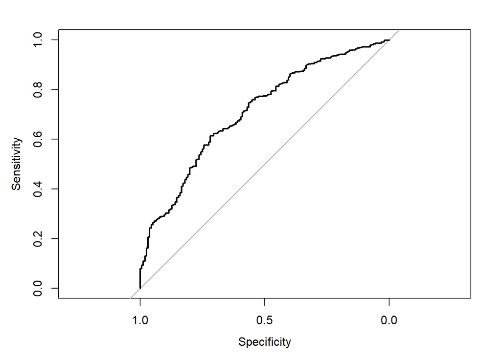

```r
plot.roc(Valid$Flight.Status, Predict_Valid_Label_Raw[,2])
```

- Naive Bayes for the Complete Data without partitions:

```r
Predict_Total_Label <- predict(nb_model, Data)
CrossTable(x = Data$Flight.Status, y = Predict_Total_Label, prop.chisq = FALSE)
```

```
##
##
##    Cell Contents
## |-------------------------|
## |                       N |
## |           N / Row Total |
## |           N / Col Total |
## |         N / Table Total |
## |-------------------------|
##
##
## Total Observations in Table:  2201
##
##
##                    | Predict_Total_Label
## Data$Flight.Status |   delayed |    ontime | Row Total |
## -------------------|-----------|-----------|-----------|
##            delayed |        41 |       387 |       428 |
##                    |     0.096 |     0.904 |     0.194 |
##                    |     0.456 |     0.183 |           |
##                    |     0.019 |     0.176 |           |
## -------------------|-----------|-----------|-----------|
##             ontime |        49 |      1724 |      1773 |
##                    |     0.028 |     0.972 |     0.806 |
##                    |     0.544 |     0.817 |           |
##                    |     0.022 |     0.783 |           |
## -------------------|-----------|-----------|-----------|
##       Column Total |        90 |      2111 |      2201 |
##                    |     0.041 |     0.959 |           |
## -------------------|-----------|-----------|-----------|
##
##
```

```r
confusionMatrix(Predict_Total_Label, Data$Flight.Status)
```

```
## Confusion Matrix and Statistics
##
##           Reference
## Prediction delayed ontime
##    delayed      41     49
##    ontime      387   1724
##
##                Accuracy : 0.8019
##                  95% CI : (0.7846, 0.8184)
##     No Information Rate : 0.8055
##     P-Value [Acc > NIR] : 0.678
##
##                   Kappa : 0.0973
##
##  Mcnemar's Test P-Value : <2e-16
##
##             Sensitivity : 0.09579
##             Specificity : 0.97236
##          Pos Pred Value : 0.45556
##          Neg Pred Value : 0.81667
##              Prevalence : 0.19446
##          Detection Rate : 0.01863
##    Detection Prevalence : 0.04089
##       Balanced Accuracy : 0.53408
##
##        'Positive' Class : delayed
##
```

```r
Predict_Total_Label_Raw <- predict(nb_model, Data, type = "raw")

roc(Data$Flight.Status, Predict_Total_Label_Raw[,2])
```

```
##
## Call:
## roc.default(response = Data$Flight.Status, predictor = Predict_Total_Label_Raw[,     2])
##
## Data: Predict_Total_Label_Raw[, 2] in 428 controls (Data$Flight.Status delayed) < 1773 cases (Data$Flight.Status ontime).
## Area under the curve: 0.6856
```

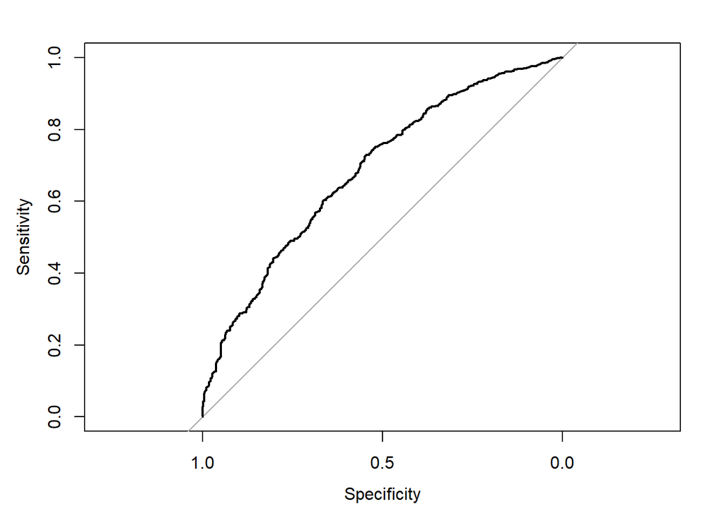

```r
plot.roc(Data$Flight.Status, Predict_Total_Label_Raw[,2])
```

Hence, the final output for the model can be determined using the complete data.

- HyperTuning

```r
nb_model_Hypertune <- naiveBayes(Flight.Status~DAY_WEEK+CRS_DEP_TIME+ORIGIN+DEST+CARRIER, data=Train, preProc = c("center", "scale","BoxCox"))
nb_model_Hypertune
```

```
##
## Naive Bayes Classifier for Discrete Predictors
##
## Call:
## naiveBayes.default(x = X, y = Y, laplace = laplace, preProc = ..1)
##
## A-priori probabilities:
## Y
##   delayed    ontime
## 0.2059046 0.7940954
##
## Conditional probabilities:
##          DAY_WEEK
## Y            Monday   Tuesday Wednesday  Thursday    Friday  Saturday
##   delayed 0.1985294 0.1470588 0.1397059 0.1323529 0.1691176 0.0625000
##   ontime  0.1286940 0.1372736 0.1439466 0.1782650 0.1849380 0.1182078
##          DAY_WEEK
## Y            Sunday
##   delayed 0.1507353
##   ontime  0.1086749
##
##          CRS_DEP_TIME
## Y         6 AM Interval 7 AM Interval 8 AM Interval 9 AM Interval
##   delayed   0.003676471   0.069852941   0.029411765   0.069852941
##   ontime    0.015252622   0.084842707   0.033365110   0.093422307
##          CRS_DEP_TIME
## Y         10 AM Interval 11 AM Interval 12 PM Interval 1 PM Interval
##   delayed    0.003676471    0.040441176    0.003676471   0.095588235
##   ontime     0.026692088    0.055290753    0.024785510   0.115347950
##          CRS_DEP_TIME
## Y         2 PM Interval 3 PM Interval 4 PM Interval 5 PM Interval
##   delayed   0.036764706   0.139705882   0.069852941   0.084558824
##   ontime    0.047664442   0.111534795   0.057197331   0.093422307
##          CRS_DEP_TIME
## Y         6 PM Interval 7 PM Interval 8 PM Interval 9 PM Interval
##   delayed   0.110294118   0.113970588   0.018382353   0.033088235
##   ontime    0.091515729   0.060057197   0.018112488   0.031458532
##          CRS_DEP_TIME
## Y         10 PM Interval
##   delayed    0.077205882
##   ontime     0.040038132
##
##          ORIGIN
## Y                BWI        DCA        IAD
##   delayed 0.09558824 0.54044118 0.36397059
##   ontime  0.06005720 0.64918970 0.29075310
##
##          DEST
## Y               EWR       JFK       LGA
##   delayed 0.3860294 0.1764706 0.4375000
##   ontime  0.2802669 0.1754051 0.5443279
##
##          CARRIER
## Y                 CO         DH         DL         MQ         OH
##   delayed 0.06250000 0.30882353 0.11029412 0.18382353 0.01102941
##   ontime  0.03813155 0.23260248 0.19542421 0.12011439 0.01811249
##          CARRIER
## Y                 RU         UA         US
##   delayed 0.22058824 0.01102941 0.09191176
##   ontime  0.16968541 0.01620591 0.20972355
```

```r
Predict_Hypertuned_Valid <- predict(nb_model_Hypertune, Valid)
head(Predict_Hypertuned_Valid)
```

```
## [1] ontime ontime ontime ontime ontime ontime
## Levels: delayed ontime
```

```r
CrossTable(x= Valid$Flight.Status, y = Predict_Hypertuned_Valid, prop.chisq = FALSE)
```

```
##
##
##    Cell Contents
## |-------------------------|
## |                       N |
## |           N / Row Total |
## |           N / Col Total |
## |         N / Table Total |
## |-------------------------|
##
##
## Total Observations in Table:  880
##
##
##                     | Predict_Hypertuned_Valid
## Valid$Flight.Status |   delayed |    ontime | Row Total |
## --------------------|-----------|-----------|-----------|
##             delayed |        12 |       144 |       156 |
##                     |     0.077 |     0.923 |     0.177 |
##                     |     0.387 |     0.170 |           |
##                     |     0.014 |     0.164 |           |
## --------------------|-----------|-----------|-----------|
##              ontime |        19 |       705 |       724 |
##                     |     0.026 |     0.974 |     0.823 |
##                     |     0.613 |     0.830 |           |
##                     |     0.022 |     0.801 |           |
## --------------------|-----------|-----------|-----------|
##        Column Total |        31 |       849 |       880 |
##                     |     0.035 |     0.965 |           |
## --------------------|-----------|-----------|-----------|
##
##
```

```r
confusionMatrix(Predict_Hypertuned_Valid, Valid$Flight.Status)
```

```
## Confusion Matrix and Statistics
##
##           Reference
## Prediction delayed ontime
##    delayed      12     19
##    ontime      144    705
##
##                Accuracy : 0.8148
##                  95% CI : (0.7875, 0.8399)
##     No Information Rate : 0.8227
##     P-Value [Acc > NIR] : 0.7477
##
##                   Kappa : 0.0739
##
##  Mcnemar's Test P-Value : <2e-16
##
##             Sensitivity : 0.07692
##             Specificity : 0.97376
##          Pos Pred Value : 0.38710
##          Neg Pred Value : 0.83039
##              Prevalence : 0.17727
##          Detection Rate : 0.01364
##    Detection Prevalence : 0.03523
##       Balanced Accuracy : 0.52534
##
##        'Positive' Class : delayed
##
```